# Team All Stars Lab 14 (4)

Johnny Tamanaha, Emily Archambault, Eugene Miller, Kaiyuan Fan, Jingzhi Zhang

12/6/2019

### Main Question

Do mothers who smoke have increased rates of premature delivery (before 270 days)?

## Overall Question, why it is important.

Analyzing how a mother’s smoking habits affect their child’s birth timing and weight is important because having that knowledge would help people make better decisions for the health of the next generation. Not only would this help lawmakers take action or doctors spread awareness about the health risks of smoking for pregnant women, but it would help pregnant women be informed about the risks that smoking has on their children.

## Team Plot

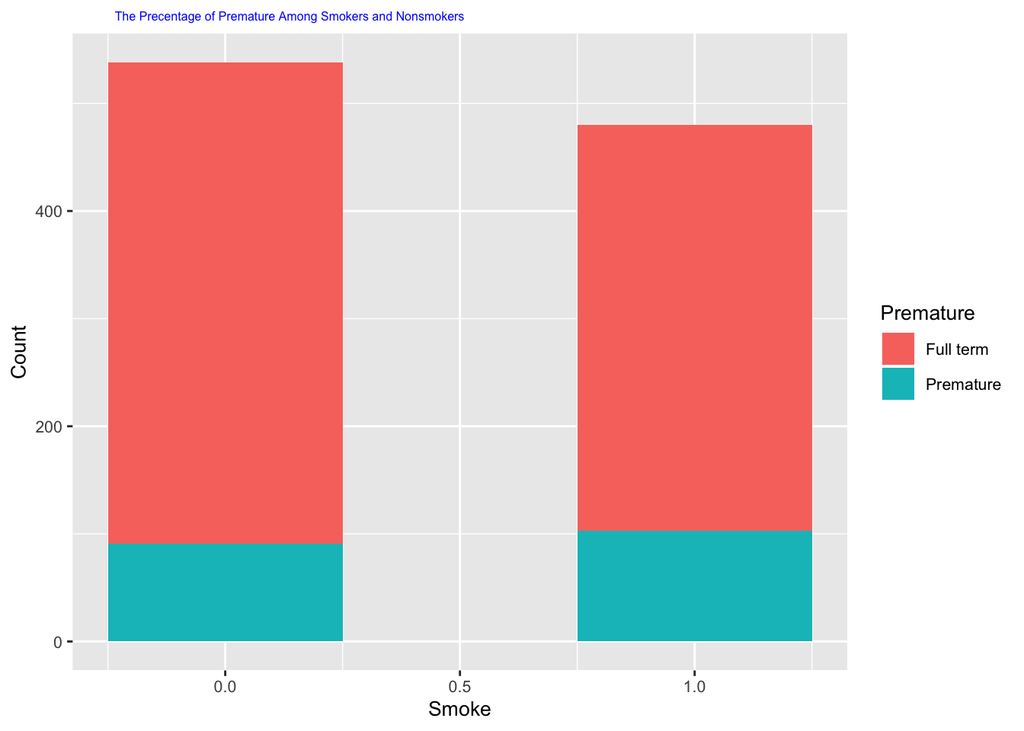

```r
ggplot(subset(babies,Premature!="NA" & smoke != "NA"), aes(smoke))  +
  geom_bar(aes(fill = Premature == 1), width=0.5)+
  labs(x= "Smoke", y="Count", fill = "premature people", title = "The Precentage of Premature Among Smokers and Nonsmokers ")+
  theme(text = element_text(face = "plain",colour = "black", size = 10, lineheight = 0.9,  hjust = 0.5),plot.title = element_text (hjust = 0.1,color="blue", size =6))+
  scale_fill_discrete(name="Premature",breaks=c("FALSE", "TRUE"),labels=c("Full term", "Premature"))
```

Statistics:

Null hypothesis: there is no difference in premature birth rate between smoking and nonsmoking mothers.

```r
data_babies <- babies %>%
  filter(Premature!="NA" & smoke != "NA")

smoke_babies <- data_babies %>%
  filter(smoke==1)
nosmoke_babies <- data_babies %>%
  filter(smoke==0)

smoke_mean <- mean(smoke_babies$Premature)
nosmoke_mean <- mean(nosmoke_babies$Premature)

mu_prem <- smoke_mean - nosmoke_mean

perm_mean <- function(perms = 1000, all_values, n_A)
{
  mu_vec <- numeric(perms)

  for (i in c(1:perms))
  {

    shuffle <- sample(all_values)

    r_A <- shuffle[1:n_A]
    r_B <- shuffle[(n_A+1):length(all_values)]

    delta_mu <- mean(r_A) - mean(r_B)

    mu_vec[i] <- delta_mu
  }

  return(mu_vec)
}

perm_babies <- perm_mean(1000, data_babies$Premature, 484)

p_babies <- 1 - sum(perm_babies < mu_prem)/1000
```

The p value of 0.05 indicates that we should reject the null hypothesis and instead conclude that there is a difference between premature birth rate in smoking and nonsmoking mothers.

## Conclusions

Do mothers who smoke have increased rates of premature delivery (before 270 days)? Our conclusion this time matched with our results when we initially did the lab (that there is a difference in premature birth rates in smoking and non-smoking mothers). For this lab, we used a permutation test to test the hypothesis.

## Individual Sections

### Eugene Miller

Subquestion: Is there a relation between parity (number of mother’s previous pregnancies) and smoking status?

This question is important because it could help us determing whether smoking generally results in a higher risk of failed pregnancy.

(Old Section)

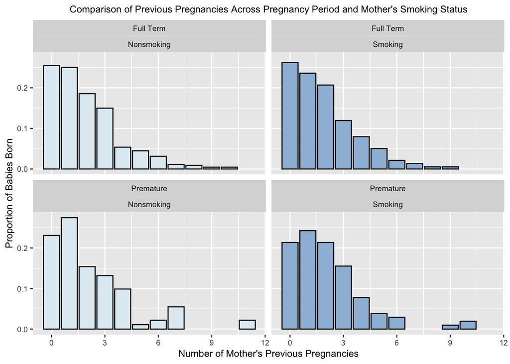

```r
ggplot(subset(babies, Premature != "NA" & smoke != "NA")) +
  geom_bar(mapping = aes(x = parity, y = ..prop.., fill = smoke == 1), show.legend = FALSE, color = "black") +
  facet_wrap(Premature~smoke, labeller = labeller(smoke = smoke.labs, Premature = prem.labs)) +
  theme(text = element_text(hjust = 0.5, size = 9.5), plot.title = element_text(hjust = 0.5, size = 9.5)) +
  labs(x = "Number of Mother's Previous Pregnancies", y = "Proportion of Babies Born", title = "Comparison of Previous Pregnancies Across Pregnancy Period and Mother's Smoking Status") +
  scale_fill_brewer(palette = 3)
```

(New Section) Statistics:

Null hypothesis: there is no difference between number of parities between nonsmoking and smoking mothers.

```r
nababies <- babies %>%
  filter(!is.na(smoke))

baby1 <- nababies %>%
  filter(smoke==1)
baby2 <- nababies %>%
  filter(smoke==0)

smokemean <- mean(baby1$parity)
nosmokemean <- mean(baby2$parity)

mu <- smokemean - nosmokemean

perm_mean <- function(perms = 1000, all_values, n_A)
{
  mu_vec <- numeric(perms)

  for (i in c(1:perms))
  {

    shuffle <- sample(all_values)

    r_A <- shuffle[1:n_A]
    r_B <- shuffle[(n_A+1):length(all_values)]

    delta_mu <- mean(r_A) - mean(r_B)

    mu_vec[i] <- delta_mu
  }

  return(mu_vec)
}

baby_perms <- perm_mean(1000, nababies$parity, 484)
p_value <- 1 - sum(baby_perms < mu)/1000
```

With a p value of 0.688 the null hypothesis is not rejected. That is to say, there is not statistical evidence that the difference in parities between smoking and nonsmoking mothers didnt occur by chance.

### Emily Archambault

Question: Is there a correlation between the pre-pregnancy weight of a mother and the weight of her child? This question is important because it could show whether the weight of the mother is a potential hidden variable that could be affecting our analysis of smokers and non-smokers.

Old Graph:

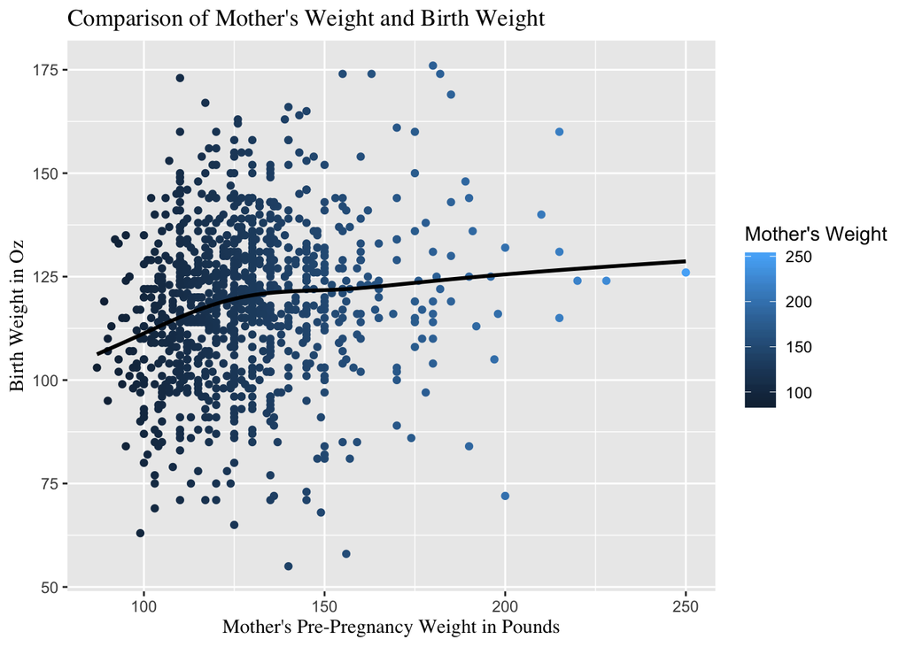

```r
ggplot(data = babies, mapping = aes(x = mpregwt, y = bwtoz, color = mpregwt)) +
geom_point() + geom_smooth(color = "black", se = FALSE) +
labs(x = "Mother's Pre-Pregnancy Weight in Pounds", y = "Birth Weight in Oz", title = "Comparison of Mother's Weight and Birth Weight", color = "Mother's Weight") +
theme(plot.title=element_text(family="Times"), axis.title.x =element_text(family = "Times"), axis.title.y = element_text(family = "Times"))
```

I previously concluded that there didn’t seem to be a correlation between the pre-pregnancy weight of a mother and the weight of her child.

New Graph:

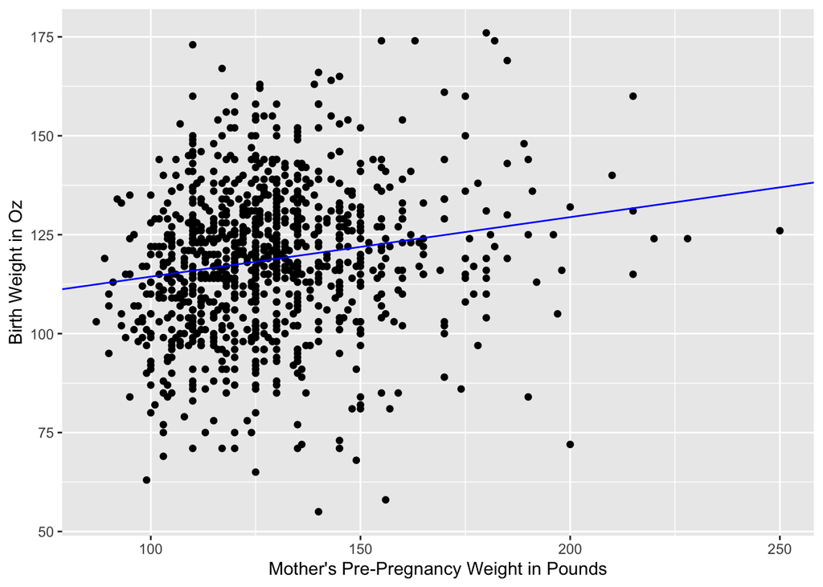

```r
ggplot(data = babies) +
  geom_point(mapping=aes(x = mpregwt, y = bwtoz)) +
  geom_abline(intercept = 99.3510, slope = 0.1505, color = "blue") + labs(x = "Mother's Pre-Pregnancy Weight in Pounds", y = "Birth Weight in Oz")
```

By fitting a linear model to the data, it mostly supports my initial analysis because while it shows there could be a slight upward trend, the correlation is very small.

### Kaiyuan Fan

Subquestion: Is premature influence the birth weigth of baby or any relationship between them?

This question is important because it will help mother to make a decision whether they want to premature or not in the future. I think it will be helpful. Old section:

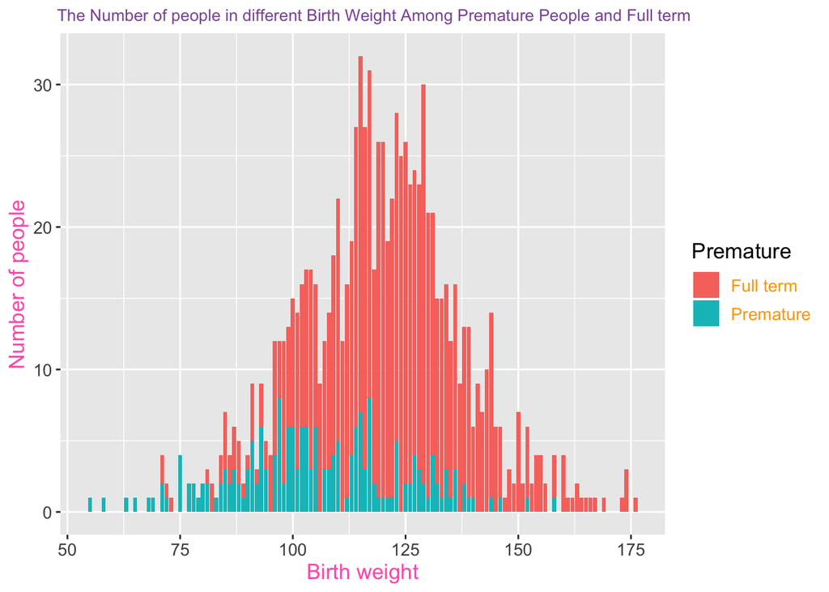

```r
ggplot(subset(babies,Premature!="NA"), aes(bwtoz))+
  geom_bar(aes(fill=Premature==1))+
  labs(x= "Birth weight", y="Number of people", fill = "premature people", title = "The Number of people in different Birth Weight Among Premature People and Full term ")+
  theme(text = element_text(face = "plain",color = "#FF63B8", size = 13, lineheight =1,  hjust = 0.5),plot.title = element_text (hjust = 0.1,color="#8C57A6", size =10), legend.text = element_text(color = "orange"), legend.title =element_text(color = "black") )+
  scale_fill_discrete(name="Premature",breaks=c("FALSE", "TRUE"),labels=c("Full term", "Premature"))
```

New section:

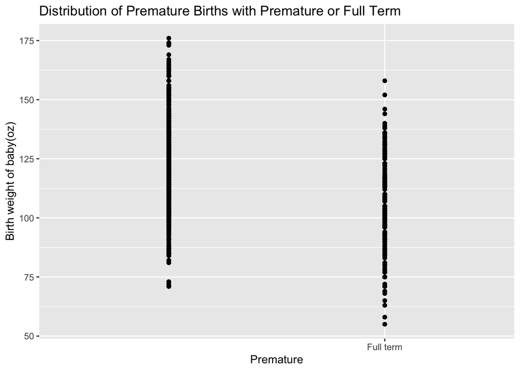

```r
library(tidyverse)
library(splines)
library(modelr)
library(tidyverse)

mod1 <- lm( bwtoz ~ Premature, data = babies)
grid <- babies %>%
  data_grid(Premature) %>%
  add_predictions(mod1)

ggplot(babies, aes(Premature,bwtoz)) +
  geom_point()+
  labs(x = "Premature", y = "Birth weight of baby(oz)", title = "Distribution of Premature Births with Premature or Full Term")+
  scale_x_discrete(limits=c("Full term", "Premature"))
```

New graph make it explicitly showing the premature has influence on the birth weight of babies.

### Johnny Tamanaha

Subquestion: Is birth weight affected by weather or not a mother has a college degree?

This question is important because knowing a correlation between mother’s education and birth weight could add to the importance of school for everyone.

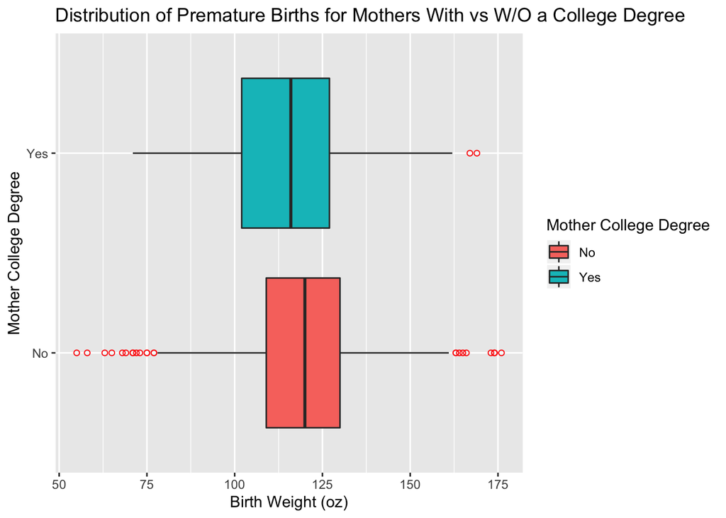

```r
ggplot(subset(babies, med!="NA")) +
  geom_boxplot(mapping=aes(x=med==1, y=bwtoz, fill=med==1), outlier.color="Red", outlier.shape=1) +
  labs(title="Distribution of Premature Births for Mothers With vs W/O a College Degree") +
  xlab("Mother College Degree") +
  ylab("Birth Weight (oz)") +
  scale_x_discrete(labels=c("No", "Yes")) +
  scale_fill_discrete(name="Mother College Degree", labels=c("No","Yes")) +
  coord_flip()
```

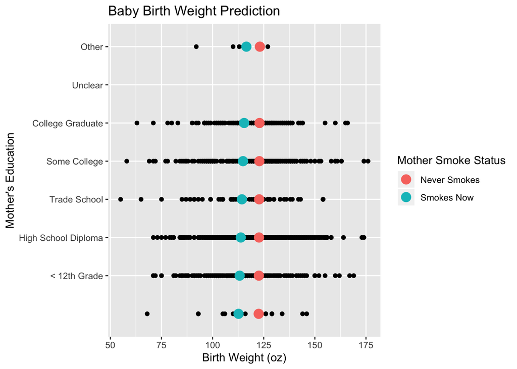

```r
babies1 <- babies %>%
  mutate(smoke_fct = factor(smoke)) %>%
  filter(smoke != "NA")
model <- lm(bwtoz ~ med * smoke_fct, data=babies1)
grid <- babies1 %>%
  data_grid(med, smoke_fct) %>%
  gather_predictions(model)
ggplot(babies1) +
  geom_point(aes(med, bwtoz)) +
  geom_point(data=grid, aes(med, pred, color=smoke_fct), size=4) +
  scale_color_discrete(name = "Mother Smoke Status", labels=c("Never Smokes", "Smokes Now")) +
  labs(title="Baby Birth Weight Prediction") +
  xlab("Mother's Education") +
  ylab("Birth Weight (oz)") +
  scale_x_discrete(limits=c("< 12th Grade", "High School Diploma", "Trade School", "Some College", "College Graduate", "Unclear", "Other")) +
  coord_flip()
```

I used the linear model function and data_grid to show the points on the graph.

Findings: My graph shows no significant correlation between mother’s education and baby birth weight, but it does show a consistent difference between non-smokers and smokers for baby birth weight in each education category.

### Jingzhi Zhang

(Old Section) Subquestion: Does the smoking status have effects on birth weights at every gestational age (number of days into pregnancy when child is born)?

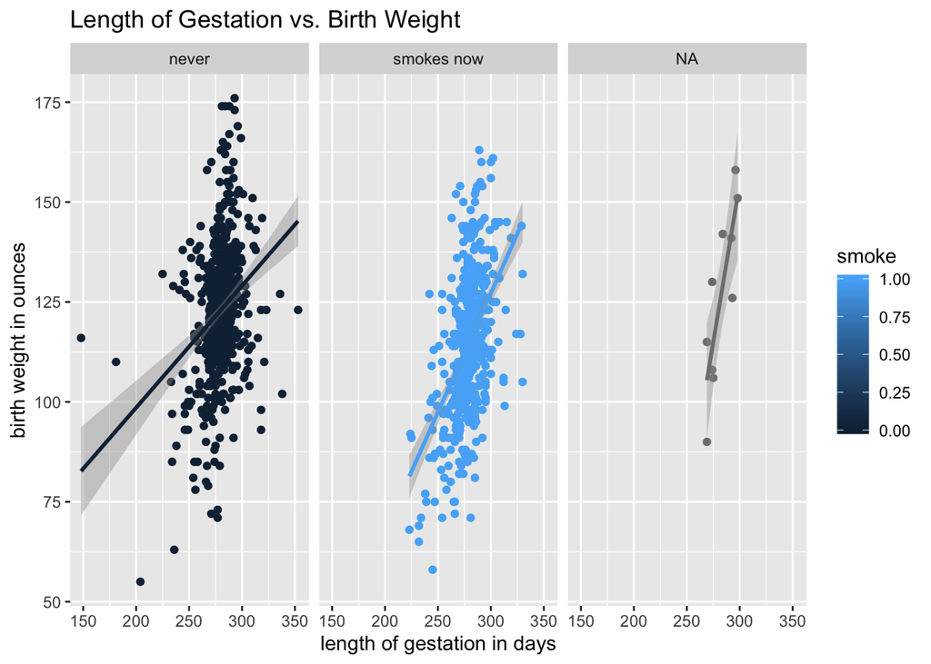

This graph shows that in the same level of birth weight in ounce, smokers have shorter length of gestation in days than nonsokers; at the same length of gestation days, babies whose mother smokes now have smaller weight than babies whose mother never smoke, which means that smoking affects the birth weights at every gestation age. Thus, as smoking is correlated with lower birth weight at every gestation age, I suggest all of the expctant should quit smoking in order to have a healthy baby.

(New Section)

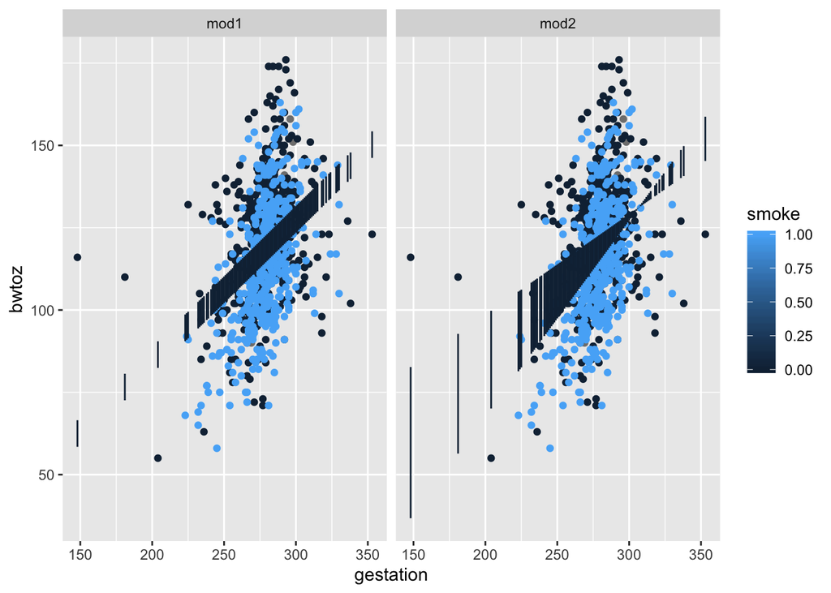

```r
library(ggplot2) # Load the librarie (you have to do this one on each new session)
library(magrittr)
library(modelr)
mod1 <- lm(bwtoz ~ gestation + smoke, data = babies)
mod2 <- lm(bwtoz ~ gestation * smoke, data = babies)

grid <- babies %>%
  data_grid(gestation, smoke) %>%
  gather_predictions(mod1, mod2)

ggplot(babies, aes(gestation, bwtoz, colour = smoke)) +
  geom_point() +
  geom_line(data = grid, aes(y = pred)) +
  facet_wrap(~ model)
```

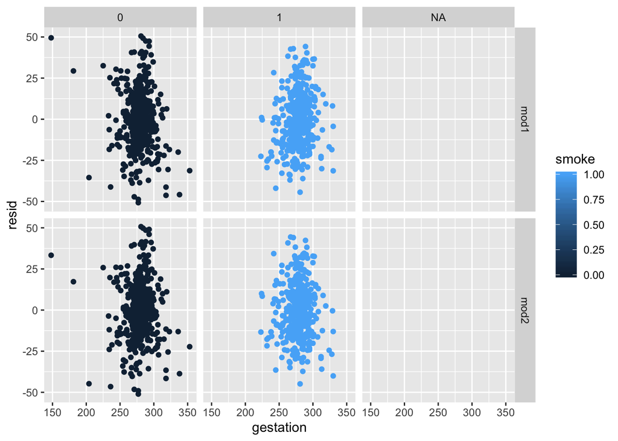

```r
babies <- babies %>%
  gather_residuals(mod1, mod2)

ggplot(babies, aes(gestation, resid, colour = smoke)) +
  geom_point() +
  facet_grid(model ~ smoke)
```

I use interactions to model the effect of smoke status on birth weights at every gestational age. It mostly supports my initial analysis because the trend looks similar. I use two models to fit this data, and there is no clear difference. —

## Individual Contribution Summaries

**Eugene Miller** : I added some statistics to our team question, and used permutation testing on my individual section.

**Emily Archambault**: I updated my orginal analysis of the relationship between a mother’s pre-pregnancy weight and birth weight using the new tool of a linear model.

**Johnny Tamanaha**: I did the plot for baby birthweight separated by mother’s education.

**Jngzhi Zhang**: For my individual part, I made a plot that shows the correlation of length of gestation in days and babies birth weight in ounces with smoker and nonsmoker. I used the geom_point, geom_smooth functions and facet_grid functions, and also use color to make points easier to see. I added labels for x and y axes as well as the title. I also used labs to substituted origenal labels of smoke. I also created the plot answering question one, and wrote the conclusions section.